# P2 - Las necesidades de la migración venezolana en el Perú

# Las principales necesidades de la migración venezolana, en el Perú desde principios del año 2022 hasta la actualidad.

# Introducción

**Relevancia**

En los últimos años, la situación que afrontó la población venezolana situada en el Perú ha ido cambiando respecto a la del año 2018, ya sea por fenómenos globales como el covid-19 o factores como la carencia de alimentos, medicinas, productos de primera necesidad, aumento de la inseguridad ciudadana, etc. Por otro lado, se sabe que el inicio de la pandemia fue una de las potenciales razones para que se produzca la migración hacia países vecinos como lo es Colombia, Ecuador o Perú. Es por ello, que a través de este estudio seremos capaces de adquirir información actualizada de la población venezolana en el Perú, por lo que el presente proyecto mostrará las necesidades más relevantes en base al perfil educativo, las condiciones de salud, empleabilidad,etc.

**Planificación** De acuerdo a la planificación, consideramos que las reuniones serían los fines de semana para verificar el respectivo avance del proyecto, de tal manera que podemos observar que 3 personas nos encargamos de la limpieza de datos de las 9 bases, y las otras 2 se encargaron de reestructurar el código y elaborar el análisis para la presentación. Asimismo, de acuerdo a la disponibilidad de todo el grupo, coordinamos para realizar una reunión general para poder ver el avance total del proyecto.

# Planificación

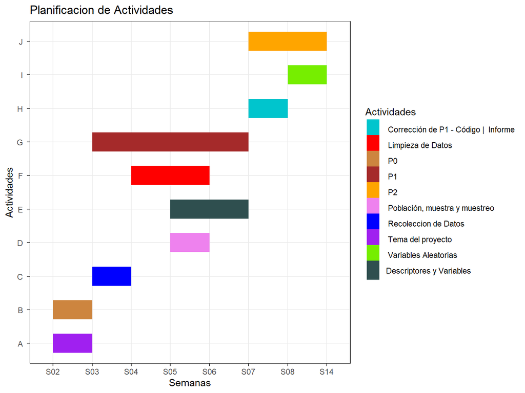

# Recolección de datos

Utilizamos 9 base de datos del INEI (Encuesta dirigida a la población venezolana que reside en el país - EMPOVE) Aproximadamente contenían 12k de observaciones y 128 variables. Luego de ello, limpiamos y solo utilizamos 20 variables de las cuales, las más relevantes están explícitas en este proyecto.

**Población, muestra y muestreo**

Población, muestra y muestreo: La población escogida son las personas migrantes venezolanas que residen en el Perú y la unidad muestral es aquella persona que vive actualmente en cualquier distrito de los 8 departamentos que contiene nuestra base de datos. El tipo de muestreo utilizado es un muestreo probabilístico estratificado.

**Contextualización**

# Pregunta de investigación

¿Cuáles son las principales necesidades que tienen los migrantes venezolanos, en el Perú desde principios del año 2022 hasta la actualidad?

# Variables

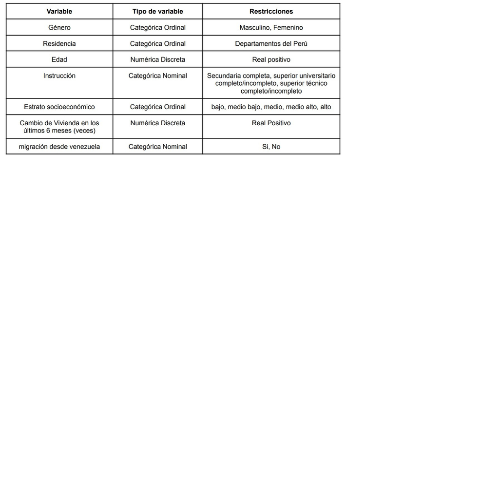

## Relación entre variables

# Variables

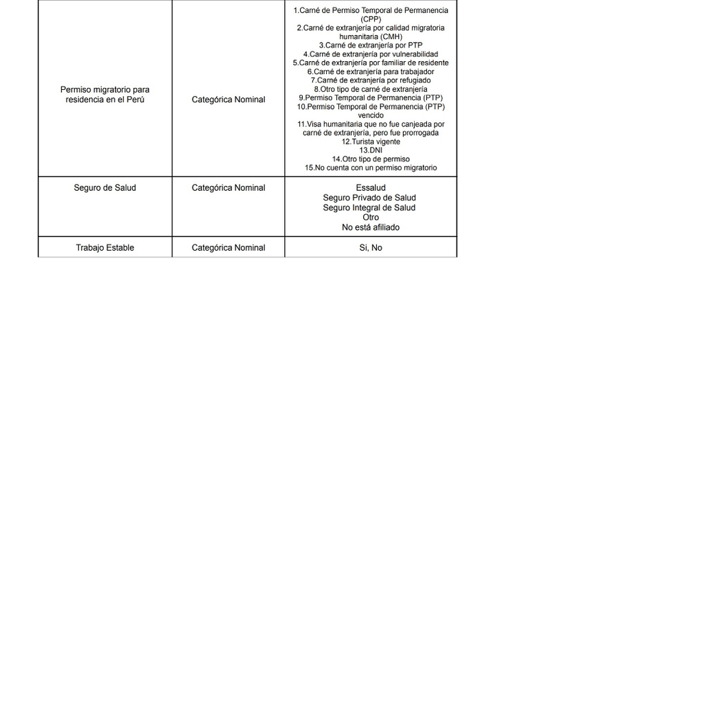

## Relación entre variables

# Variables

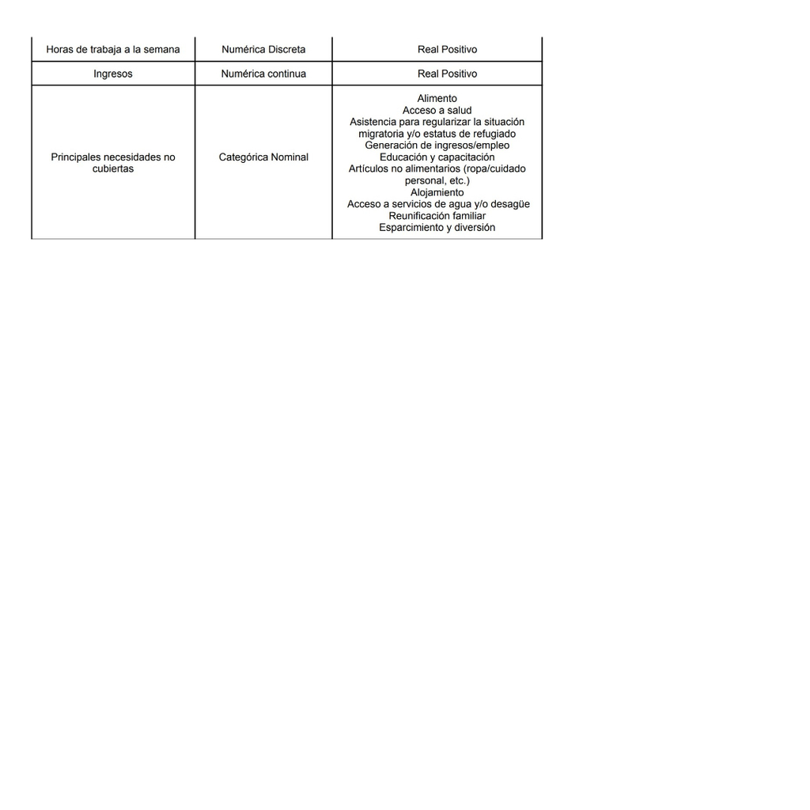

## Relación entre variables

# Limpieza de bases de datos

Unir las bases de datos

Seleccionar las variables que se utilizarán

Contar las observaciones y variables

```
## [1] 27877     7
```

Contar los datos faltantes y no faltantes

```
## [1] 89665
```

```
## [1] 105474
```

Cantidad de datos faltantes por variable antes de reemplazar los NAs con 0s

```
## DEPARTAMENTO      ESTRATO        P111A         P204       P205_A         P208
##            0            0        26978        15390        15635        15390
##         P307
##        16272
```

Cambiar el nombre de las variables para que se entienda mejor

Reemplazar los NAs con 0s

Cantidad de datos faltantes por variable después de reemplazar los NAs con 0s

```
##       DEPARTAMENTO            ESTRATO      CAMBIO_DE_VIV               SEXO
##                  0                  0                  0                  0
##               EDAD       MIGRO_DE_VEN PERMISO_MIGRATORIO
##                  0                  0                  0
```

```
##  [1] "CCDD"         "DEPARTAMENTO" "CCPP"         "PROVINCIA"    "CCDI"
##  [6] "DISTRITO"     "CIUDAD"       "CONGLOMERADO" "NSELV"        "VIVIENDA"
## [11] "THOGAR"       "NHOGAR"       "ESTRATO"      "VRESFIN"      "RESFIN"
## [16] "P15"          "P15_N"        "P200_N"       "P313_N"       "P313_1"
## [21] "P313_2"       "P313_3"       "P313_4"       "factorfinal"
```

[output not shown]

[output not shown]

[output not shown]

[output cut: 17 more lines]

```
##  [1] "DEPARTAMENTO"   "PROVINCIA"      "DISTRITO"       "CIUDAD"
##  [5] "CONGLOMERADO"   "NSELV"          "VIVIENDA"       "THOGAR"
##  [9] "NHOGAR"         "ESTRATO"        "VRESFIN"        "RESFIN"
## [13] "TOTALES"        "INGRESODINERO"  "INGRESOESPECIE"
```

```
## Rows: 10,242
## Columns: 15
## $ DEPARTAMENTO   <chr> "TUMBES", "TUMBES", "TUMBES", "TUMBES", "TUMBES", "TUMB~
## $ PROVINCIA      <chr> "TUMBES", "TUMBES", "TUMBES", "TUMBES", "TUMBES", "TUMB~
## $ DISTRITO       <chr> "TUMBES", "TUMBES", "TUMBES", "TUMBES", "TUMBES", "TUMB~
## $ CIUDAD         <chr> "Tumbes", "Tumbes", "Tumbes", "Tumbes", "Tumbes", "Tumb~
## $ CONGLOMERADO   <chr> "00034", "00034", "00034", "00034", "00036", "00036", "~
## $ NSELV          <chr> "00240", "00240", "00240", "00240", "00200", "00200", "~
## $ VIVIENDA       <dbl> 21, 21, 21, 21, 25, 25, 25, 25, 16, 17, 17, 17, 17, 17,~
## $ THOGAR         <dbl> 1, 1, 1, 1, 1, 1, 1, 1, 1, 1, 1, 1, 1, 1, 1, 1, 1, 1, 1~
## $ NHOGAR         <dbl> 1, 1, 1, 1, 1, 1, 1, 1, 1, 1, 1, 1, 1, 1, 1, 1, 1, 1, 1~
## $ ESTRATO        <chr> "2.Medio bajo", "2.Medio bajo", "2.Medio bajo", "2.Medi~
## $ VRESFIN        <chr> "1.Completa", "1.Completa", "1.Completa", "1.Completa",~
## $ RESFIN         <chr> "1.Completa", "1.Completa", "1.Completa", "1.Completa",~
## $ TOTALES        <dbl> 60, 60, NA, NA, 51, 55, NA, 6, 56, 105, 60, NA, NA, NA,~
## $ INGRESODINERO  <dbl> 1150, 400, NA, NA, NA, NA, NA, NA, NA, NA, NA, NA, NA, ~
## $ INGRESOESPECIE <dbl> 0, 0, NA, NA, NA, NA, NA, NA, NA, NA, NA, NA, NA, NA, N~
```

```
## [1] 15933
```

```
## [1] 15933
```

```
##
##  FALSE   TRUE
## 137697  15933
```

```
## [1] 4203
```

```
## [1] 4203
```

```
## [1] 6039
```

```
## [1] 6039
```

# Limpieza de Variables

#### Limpieza de la variable VRESFIN

```
## [1] "1.Completa"   "2.Incompleta"
```

VRESFIN : Limpio.

#### Limpieza de la variable RESFIN

```
## [1] "1.Completa"   "2.Incompleta"
```

RESFIN : Limpio.

#### Limpieza de la variable TOTALES

```
##   [1]  60  NA  51  55   6  56 105  66  43  32  77   7  14  41   2  72  36  21
##  [19]  70  48  45  84  78  52  65  18   5  54  49  22  10  59  16  50   3   0
##  [37]  40  35  63  42   4  81  28  15  30  39  64  24  91  75  71  69  44  38
##  [55]  95  12  80  20  73   8  11  98  83  90  25   1  27  79  58  76   9  68
##  [73]  61  26  57 112  85  53  33  46  29  34  88  82  62  47 108  67  74 102
##  [91]  94  86  17 104  97  13  37 114  96  31  19 109  93  23  99  89  87  92
## [109] 100 101 119
```

TOTALES : Limpio.

#### Limpieza de la variable INGRESODINERO

```
##   [1] 1150  400   NA  200 1516  649  300   20   25   30  720 1200  900  920  360
##  [16]  120  250  500  140   40  180  210   54  450  248  175  280  600   50  220
##  [31]   80   15  100   10  270  240   70   60   45  212  380  750  534   35   22
##  [46]  350  930   41 1300 1100 1000  150  420  475   36  588 1024  312   31 1500
##  [61] 2000 1700  800  186 1600 1800  650  470 3300  260  700  950  178 1400  960
##  [76]  680  465  550 1085  850 1170  375  480  520  440  980  235  510  320 1559
##  [91]  693 2100  758  325  170  160  330  501  435   90  730  830  125  780  230
## [106] 2500  222 1099  490 1098  860  466 4000  232  540  145 1050  814 4500  190
## [121]  425  645  820  670  183 2150  537  590  233  130   42  243  282 2020  185
## [136]  275   17  215  430 1213  910 2003  287  460  196   63  345  740  307  310
## [151]  238  370  840  560  437  274 2300  156  526  340  620  468  530   55 3500
## [166]  237 1746 1350 3000  479  289  640 1015  271 5700 1080 1850  630  710   75
## [181]  245 2700 1250 9000  225  315  308 1208  585 2200  390  355 6093  979  790
## [196]  244  165 3400  135 1465   85 1320  265  880    0  753   96 1030   86  326
## [211] 8000 1615  216  715 1819 1640 1290  940 1083 1160 1900  660  199  463  963
## [226]  515 1386   78  247  290 1040  385   43  580   33   72 4810  198 9500  433
## [241] 5500 2800  105 8600 1039 1299  455 6000  458  970  108  745  155  444  796
## [256]  266  535 7000  410  342   28  110  405  368  885  163 1443 1440  965   27
## [271]  813  417  987  870  236  682  779 4200  292 1530  217  485  565  195   68
## [286] 1135  335 2400 3200  528   56  205  173  462  545  284  915  522
```

INGRESODINERO : Limpio.

#### Limpieza de la variable INGRESOESPECIE

```
##   [1]    0   NA   10  180  280   60    5  105   48   72   63   90   56  140  120
##  [16]    8   43   15    7   34   12  600   14   75  300   54   96   16   24   32
##  [31]   22   36   18  154   70   50  100   20  200  150    3  500   42   52  450
##  [46]   82   80  250  224    2   40  375  240   21  255  225  119   49  546  195
##  [61]  144  130  260    9    6   13  168  222   30  560   28  132  455   84   35
##  [76]  155  400   17   76   47  350  145   62   53  340   66   78  114  192   25
##  [91]   79  210  174  364  102   45   98  106  338  135  126  650  270  169  490
## [106]   11  779  303  345   81  182  390  360   65  117  133   74  165  125  239
## [121] 1091  384  156   64  234  108  122   57    1 1000  198   58  228   46  109
## [136]  273  208  900  630  128  112   44  288   69  216  312  289   87 1080  196
## [151]   77  391  160  220   26  389  104
```

INGRESOESPECIE : Limpio.

[output not shown]

```
## Rows: 10,242
## Columns: 24
## $ DEPARTAMENTO        <chr> "TUMBES", "TUMBES", "TUMBES", "TUMBES", "TUMBES", ~
## $ PROVINCIA           <chr> "TUMBES", "TUMBES", "TUMBES", "TUMBES", "TUMBES", ~
## $ DISTRITO            <chr> "TUMBES", "TUMBES", "TUMBES", "TUMBES", "TUMBES", ~
## $ CIUDAD              <chr> "Tumbes", "Tumbes", "Tumbes", "Tumbes", "Tumbes", ~
## $ CONGLOMERADO        <chr> "00034", "00034", "00034", "00034", "00036", "0003~
## $ NSELV               <chr> "00240", "00240", "00240", "00240", "00200", "0020~
## $ VIVIENDA            <dbl> 21, 21, 21, 21, 25, 25, 25, 25, 16, 17, 17, 17, 17~
## $ THOGAR              <dbl> 1, 1, 1, 1, 1, 1, 1, 1, 1, 1, 1, 1, 1, 1, 1, 1, 1,~
## $ NHOGAR              <dbl> 1, 1, 1, 1, 1, 1, 1, 1, 1, 1, 1, 1, 1, 1, 1, 1, 1,~
## $ ESTRATO             <chr> "2.Medio bajo", "2.Medio bajo", "2.Medio bajo", "2~
## $ VRESFIN             <chr> "1.Completa", "1.Completa", "1.Completa", "1.Compl~
## $ RESFIN              <chr> "1.Completa", "1.Completa", "1.Completa", "1.Compl~
## $ NECESALIMENTO       <chr> "0", "0", "0", "0", "0", "0", "0", "0", "0", "0", ~
## $ NECESSALUD          <chr> "0", "0", "0", "0", "2.Acceso a salud", "0", "0", ~
## $ NECESSITUACION      <chr> "0", "0", "0", "0", "0", "0", "0", "0", "0", "0", ~
## $ NECESINGRESOSEMPLEO <chr> "4.Generación de ingresos/empleo", "4.Generación d~
## $ NECESEDUCACION      <chr> "0", "0", "0", "0", "0", "0", "5.Educación y capac~
## $ NECESPERSONALES     <chr> "0", "0", "6.Artículos no alimentarios (ropa/cuida~
## $ NECESALOJAMIENTO    <chr> "0", "0", "0", "0", "0", "7.Alojamiento", "7.Aloja~
## $ NECESAGUA           <chr> "0", "0", "0", "0", "0", "0", "0", "0", "0", "0", ~
## $ NECESFAMILIA        <chr> "9.Reunificación familiar", "9.Reunificación famil~
## $ NECESDIVERSION      <chr> "10.Esparcimiento y diversión", "0", "10.Esparcimi~
## $ NECESOTROS          <chr> "0", "0", "0", "0", "0", "0", "0", "0", "0", "0", ~
## $ NECESESPECIFICAR    <chr> "0", "0", "0", "12.SUS NECESIDADES YA ESTÁN CUBIER~
```

```
## [1] 180
```

```
## [1] 180
```

```
##
##  FALSE   TRUE
## 245628    180
```

```
## [1] 10227
```

```
## [1] 10227
```

```
## [1] 15
```

```
## [1] 15
```

# Limpieza de Variables

#### Limpieza de la variable NECESALIMENTO

```
## [1] "0"           "1.Alimentos" NA
```

NECESALIMENTO : Limpio.

#### Limpieza de la variable NECESSALUD

```
## [1] "0"                "2.Acceso a salud" NA
```

NECESSALUD : Limpio.

#### Limpieza de la variable NECESSITUACION

```
## [1] "0"
## [2] "3 Asistencia para regularizar la situación migratoria y/o estatus de refugiado"
## [3] NA
```

NECESSITUACION : Limpio.

#### Limpieza de la variable NECESINGRESOSEMPLEO

```
## [1] "4.Generación de ingresos/empleo" "0"
## [3] NA
```

NECESINGRESOSEMPLEO : Limpio.

#### Limpieza de la variable NECESEDUCACION

```
## [1] "0"                          "5.Educación y capacitación"
## [3] NA
```

NECESEDUCACION : Limpio.

#### Limpieza de la variable NECESPERSONALES

```
## [1] "0"
## [2] "6.Artículos no alimentarios (ropa/cuidado personal, etc.)"
## [3] NA
```

NECESPERSONALES : Limpio.

#### Limpieza de la variable NECESALOJAMIENTO

```
## [1] "0"             "7.Alojamiento" NA
```

NECESALOJAMIENTO : Limpio.

#### Limpieza de la variable NECESAGUA

```
## [1] "0"
## [2] "8.Acceso a servicios de agua y/o desagüe"
## [3] NA
```

NECESAGUA : Limpio.

#### Limpieza de la variable NECESFAMILIA

```
## [1] "9.Reunificación familiar" "0"
## [3] NA
```

NECESFAMILIA : Limpio.

#### Limpieza de la variable NECESDIVERSION

```
## [1] "10.Esparcimiento y diversión" "0"
## [3] NA
```

NECESDIVERSION : Limpio.

#### Limpieza de la variable NECESOTROS

```
## [1] "0"                 NA                  "11.Otra necesidad"
```

NECESOTROS : Limpio.

```
## [1] "0"
## [2] "12.SUS NECESIDADES YA ESTÁN CUBIERTAS"
## [3] NA
```

NECESESPECIFICAR : Limpio

[output not shown]

```
##  [1] "DEPARTAMENTO" "PROVINCIA"    "DISTRITO"     "CIUDAD"       "CONGLOMERADO"
##  [6] "NSELV"        "VIVIENDA"     "THOGAR"       "NHOGAR"       "ESTRATO"
## [11] "VRESFIN"      "RESFIN"
```

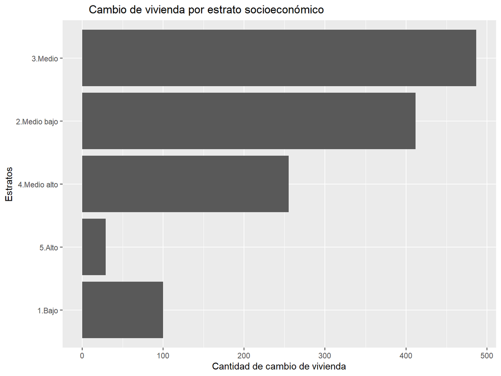

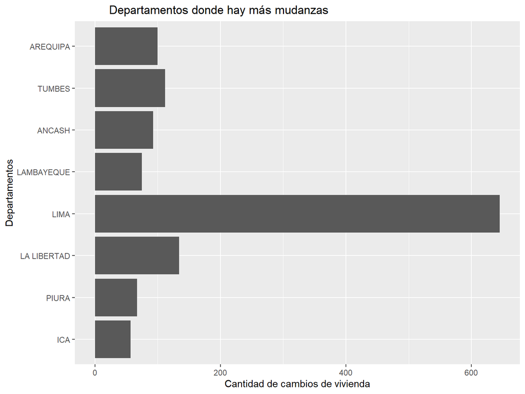

### **Horas de trabajo a la semana = TOTALES**

Nota: los datos atípicos hacia la izquierda representan el desempleo y hacia la derecha la posible explotación debido a la gran cantidad de horas por semana.

```
## [1] 119
```

```
##    Min. 1st Qu.  Median    Mean 3rd Qu.    Max.    NA's
##     0.0    41.0    54.0    52.1    66.0   119.0    3855
```

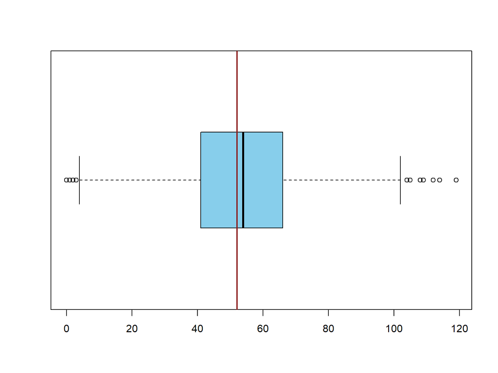

Nota 2: Irregularidad laboral debido a la gran cantidad de horas de trabajo a la semana.

### **Horas de Trabajo por semana clasificada por Estratos**

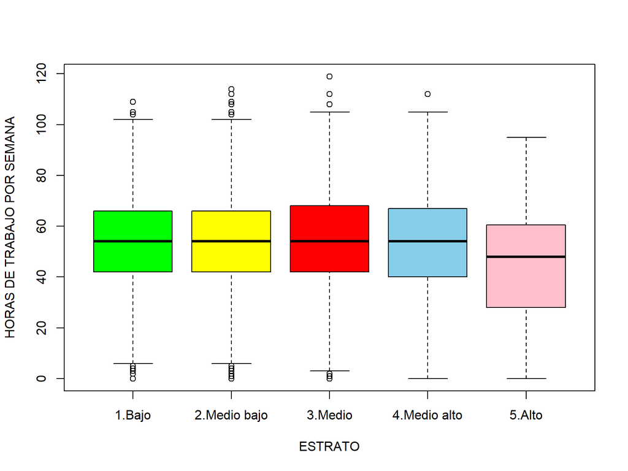

**DEPARTAMENTO vs ESTRATO**

Relacionamos 2 variables cualitativas y todas sus posibilidades. De esta manera, podemos decir que el Estrato Medio es el que más predomina a lo largo de todo el Perú y distribuido en 8 de los 24 departamentos.

```
##
##               1.Bajo 2.Medio bajo 3.Medio 4.Medio alto 5.Alto
##   ANCASH          82          220     278           80     53
##   AREQUIPA        45          222     214           70      3
##   ICA             65          189     192           76     12
##   LA LIBERTAD    160          394     368          188     28
##   LAMBAYEQUE      77          232     149          109     25
##   LIMA           574         1374    2117         1256     87
##   PIURA          122          290     117           64      0
##   TUMBES          80          211     209          136     74
```

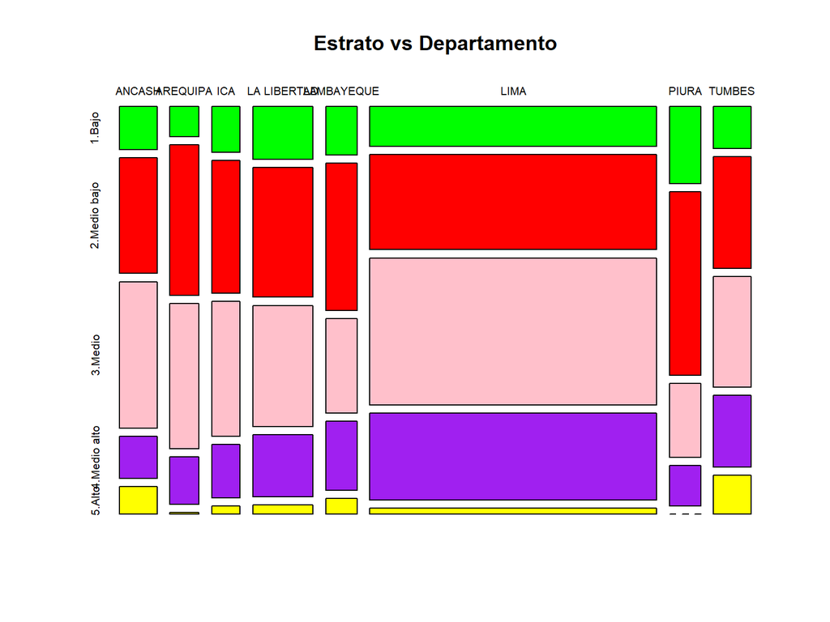

# Descriptores Numéricos

```
##        Horas_Semanales Ingreso_Dinero Edad  Migrantes_Venezuela
## Min    0               0              0     1
## Max    119             9500           98    15
## Mean   52.1            511.03         11.42 4.11
## Median 54              330            0     4
## SD     22.14           620.28         16.73 2.08
## CV     0.43            1.21           1.47  0.51
## IQR    25              400            24    2
```

# **Análisis Probabilístico**

# **Modelos de Variable Discreta**

### **Distribución Binomial Negativa**

Si bien no realizamos encuestas para obtener una base de datos y así trabajar el respectivo proyecto. Muchos de los demás proyectos si lo realizaron de esta manera y como incentivo ofrecieron un sorteo ya sea monetario o con alguna promoción. Asimismo, a manera de ejemplo de aplicación de variables aleatorias, si hiciéramos un sorteo en donde solamente se escojan 2 ganadores. Convenientemente elegiremos a los participantes teniendo como criterio el Estrato socio-económico de acuerdo al Departamento al que pertenezcan.

$DEPARTAMENTO vs ESTRATO$

```r
tabEstratoyDepartamento
```

```
##
##               1.Bajo 2.Medio bajo 3.Medio 4.Medio alto 5.Alto
##   ANCASH          82          220     278           80     53
##   AREQUIPA        45          222     214           70      3
##   ICA             65          189     192           76     12
##   LA LIBERTAD    160          394     368          188     28
##   LAMBAYEQUE      77          232     149          109     25
##   LIMA           574         1374    2117         1256     87
##   PIURA          122          290     117           64      0
##   TUMBES          80          211     209          136     74
```

- Éxito -> personas de Estrato Socio-económico - Bajo en Lima (574)
- Fracaso -> personas de cualquier departamento con el mismo Estrado Socio-económico.

Variable aleatoria: 𝑿= # de sorteos realizados hasta tener k éxitos. Variable aleatoria en Rstudio: Y = # de fracasos hasta obtener k éxitos. $X = Y + K ➜ Y = X - k$

- P(éxito) : 574 (# personas de Estrato - Bajo en Lima) / 1205 (# total de personas del Estrato Bajo)
- K : queremos 2 ganadores que pertenezcan al Estrato Bajo en Lima

$Definimos variables en R:$

```r
X = 2
k = 2
total = 1205 # total de personas del Estrato Bajo
CF = 574     # total de Lima del Estrato Bajo
PE = CF/total

choose(X-1, k-1)*(PE^k)*((1-PE)^(X-k))
```

```
## [1] 0.2269079
```

$Con el comando de Rstudio "dnbinom":$

```r
dnbinom(X-k, k, PE)
```

```
## [1] 0.2269079
```

$¿Si quisiéramos la probabilidad de obtener a los ganadores pertenecientes a otro Departamento y Estrado?$ $Ejemplo: Ica - Estrato Medio$

```r
X = 2
k = 2
total = 3644 # total de personas del Estrato Medio
CF = 192     # total de Ica del Estrato Medio
PE = CF/total

choose(X-1, k-1)*(PE^k)*((1-PE)^(X-k))
```

```
## [1] 0.002776168
```

$Con el comando de Rstudio "dnbinom":$

```r
dnbinom(X-k, k, PE)
```

```
## [1] 0.002776168
```

### **Distribución Hipergeométrica**

Se registraron 1283 mudanzas de las cuales 645 se dieron en Lima y 57 en Ica, si tomamos como muestra 100 casos sin reemplazo:

¿Cuál es la probabilidad de que…

1. más de la mitad de los casos sean de Lima?
2. más de 1/4 sean de Lima?
3. más de la mitad sean de Ica?

$Definimos$

Experimento aleatorio: Sacar un caso sobre cambio de vivienda y el departamento donde sucede. Muestreo sin reemplazo.

- X : Cantidad de casos registrados de cambios de vivienda en Lima. contenidos en la muestra. X = {0, n}
- N : casos totales registrados en el Perú
- r : casos de Lima.
- ri: casos de Ica
- n : muestra de la cantidad de casos registrados en el Perú

```r
N = casosTotalesRegistrados
r = casosLima
ri = casosIca
n = 100;

# a.)
phyper(49,r, N-r, n, lower.tail = FALSE)
```

```
## [1] 0.5639555
```

```r
# b.)
phyper(24, r, N-r, n, lower.tail = FALSE)
```

```
## [1] 1
```

```r
# c.)
phyper(49, ri, N-ri, n, lower.tail = FALSE)
```

```
## [1] 6.227427e-54
```

Explicación:

En primer lugar, la variable sigue una distribución hipergeométrica ya que: la población es finita (N elementos); cada elemento puede caracterizarse como éxito o fracaso (“si” provenien o “no” de Lima); hay “r” éxitos y “N-r” fracasos; y se saca un muestreo sin reemplazo con misma probabilidad de que los elementos sean elegidos.

En el inciso a) obtuvimos que la probabilidad de que más de la mitad de los casos sean de Lima es de prácticamente la mitad ya que es 0.56. Por otro lado, en el inciso b) se observa que la probabilidad de que más de 1/4 de los casos sean de Lima ya que la probabilidad es 1. Por último en el inciso c) observamos que es prácticamente imposible que más de la mitad de los casos sean provenientes de Ica ya que su probabilidad es 0.

Gracias a este experimento aleatorio y el análisis del mismo podemos comprender de mejor manera qué tan dominante fue Lima con respecto a la proveniencia de los casos de mudanzas en el Perú en el último año.

# **Modelos de Variable Continua**

### **Distribución Normal**

$Cantidad de horas de trabajo a la semana$

De acuerdo a las conclusiones sobre la cantidad de horas que trabajan los migrantes venezolanos a la semana, se tiene que el promedio es de 52 horas. Por lo tanto, para calcular por intervalos dicha variable cuantitativa se busca su distribución normal, Para ello, es necesario saber su desviación estándar y su media.

Variable continua: 𝑿=# Cantidad de horas trabajadas a la semana.

$¿Que porcentaje de migrantes venezolanos trabaja menos de 50 horas?$

```r
media <- mean(TOTALES,na.rm=TRUE)
#media
desv_standar <- sd(TOTALES,na.rm=TRUE)
#desv_standar
x <- 50
(pnorm(x, media, desv_standar))*100
```

```
## [1] 46.2281
```

$¿Que porcentaje de migrantes venezolanos trabaja entre 50 y 70 horas?$

$Con el comando de Rstudio "pnorm":$

```r
(pnorm(70, media, desv_standar) - pnorm(50, media, desv_standar))*100
```

```
## [1] 32.83379
```

$¿Que porcentaje de migrantes venezolanos trabaja mas de 50 horas?$

$Con el comando de Rstudio "pnorm":$

```r
(1 - pnorm(x, media, desv_standar))*100
```

```
## [1] 53.7719
```

```r
(pnorm(x, media, desv_standar, lower.tail = F))*100
```

```
## [1] 53.7719
```